# Assignment4

Jose Rodriguez

2022-10-05

## Overview

In this file we explore how to tidy wide data. Tidying data makes it much easier for applications to interpret. In this file we will also show how it becomes much easier to visualize data after converting it to long format.

We first begin by loading our working data. In this instace we are using a .csv file hosted in a public github repository. We will use the url() function to read our raw .csv values with the read_csv() function. We can think of this just like a mathematical equation surrounded by parenthesis; the functionction execute from the inside out.

```r
#load in data into a dataframe
urlfile <- 'https://raw.githubusercontent.com/jlixander/DATA607/main/Assignment4/data.csv'
df1 <- read_csv(url(urlfile))
```

```
## -------------------------------------------------------- Delimiter: "," chr
## (2): ...1, ...2 dbl (5): Los Angeles, Phoenix, San Diego, San Francisco,
## Seattle
```

```r
View(df1)
```

Additionally, we found some other quirks in the data. Our column names have space in between words which makes it hard to refer to it in our script. The first two columns do not have a column name. Row 3 of our dataset is completely empty. Lastly, we will need to fill in the blank values for the missing airline names.

## Check Data/Tidy Data

```r
#Remove all white spaces from column names
names(df1) <- gsub(" ", "_", names(df1))

#Give column 1 and 2 names
colnames(df1)[1] <- "Airline"
colnames(df1)[2] <- "OnTime_Delayed"

#Remove empty row
df1 <- df1[-c(3),]

#Fill empty values for Airline
df1 <- df1 %>%
  fill(Airline)

View(df1)
```

#Pivot data

Using long format data is crucial in data analytics.In this case we have a wide format. To fix this we will use the function pivot_longer() that will allow us to transpose our wide data into the desired long format.

```r
df_longer <- df1 %>%
  pivot_longer(cols = c(Los_Angeles,Phoenix, San_Diego, San_Francisco, Seattle),
               names_to = "Airport",
               values_to = "Flt_cnt"
               )
View(df_longer)
```

```r
sapply(df_longer, class)
```

```
##        Airline OnTime_Delayed        Airport        Flt_cnt
##    "character"    "character"    "character"      "numeric"
```

```r
#Convert Flt_cnt column to int
df_longer$Flt_cnt <- as.numeric(as.character(df_longer$Flt_cnt))
```

## Subsetting Data

In this step we subset our data to the time of departure. We want to segregate on-time flights from those delayed so that we can better represent a comparison between Airlines. We use the filter() function to accomplish this by feeding in our condition.

```r
ot_df <- filter(df_longer, OnTime_Delayed == "on time")
delay_df <- filter(df_longer, OnTime_Delayed == "delayed")
```

# Visuals

In our visual we will plot line graphs to compare our airlines and their respective departure counts. Additionally, we will also take a look at airports. This is an alternative approach where we might be able to deduce that the airport plays a role in the rate of delayed flights.

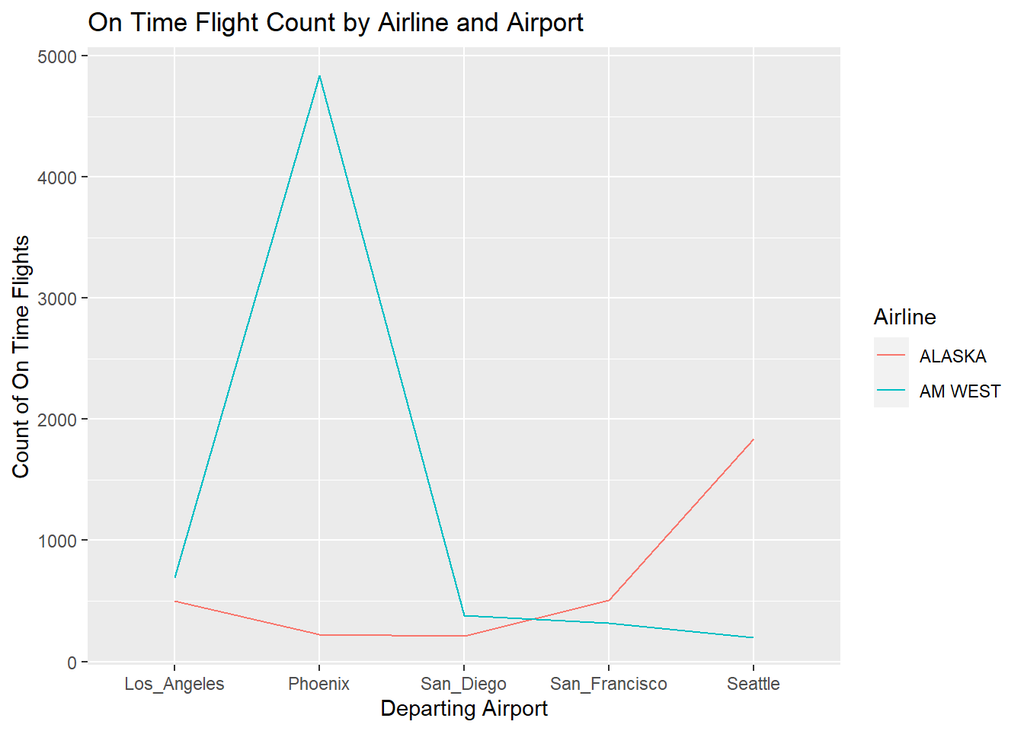

```r
#Create a Line graph showing how on time flights compare for airlines
ot_df |>
  ggplot(aes(x=Airport, y=Flt_cnt, group=Airline, color=Airline))+
  geom_line() +
  labs(
    title = "On Time Flight Count by Airline and Airport",
    x = "Departing Airport",
    y = "Count of On Time Flights",
  )
```

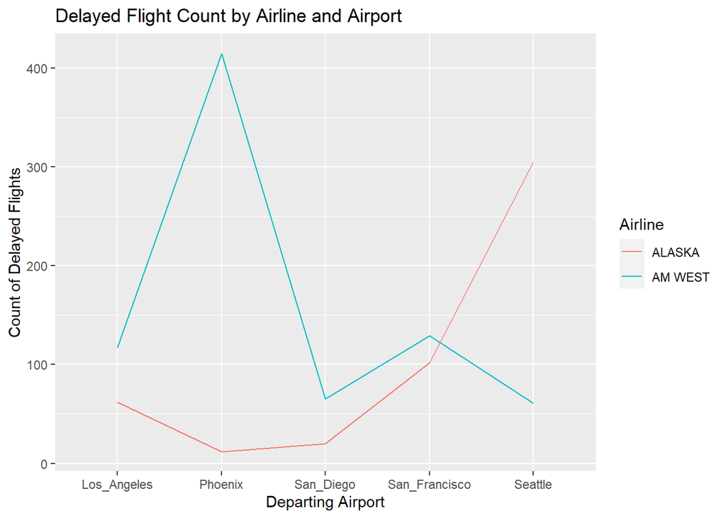

```r
#Create a Line graph showing how delayed flights compare for airlines
delay_df |>
  ggplot(aes(x=Airport, y=Flt_cnt, group=Airline, color=Airline))+
  geom_line() +
  labs(
    title = "Delayed Flight Count by Airline and Airport",
    x = "Departing Airport",
    y = "Count of Delayed Flights",
  )
```

```r
#For each airline find the proportion of On Time vs Delayed flights.
perc <- df_longer |>
  group_by(Airline, OnTime_Delayed) |>
  summarise(Flt_cnt = sum(Flt_cnt))
```

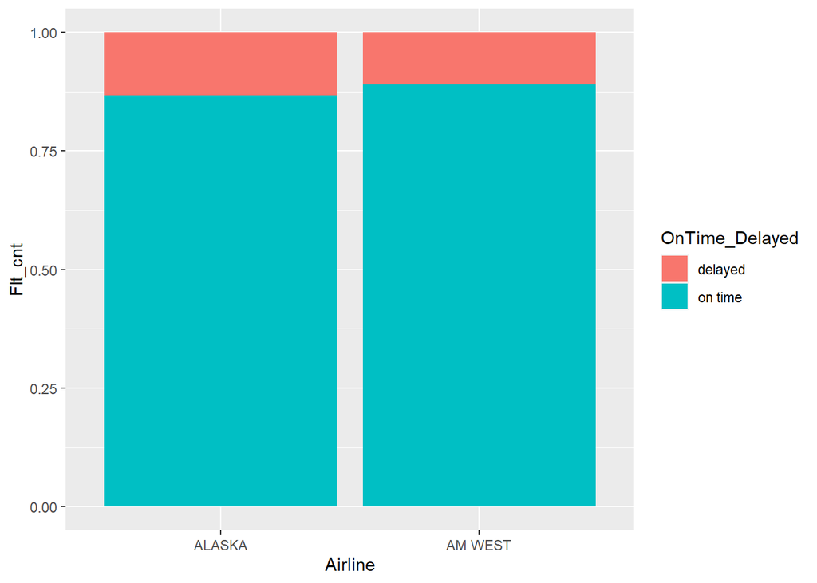

```r
ggplot(perc, aes(fill=OnTime_Delayed, y=Flt_cnt, x=Airline)) +
  geom_bar(position="fill", stat="identity")
```

```r
#For each airport find the proportion of On Time vs Delayed flights.
perc <- df_longer |>
  group_by(Airport, OnTime_Delayed) |>
  summarise(Flt_cnt = sum(Flt_cnt))
```

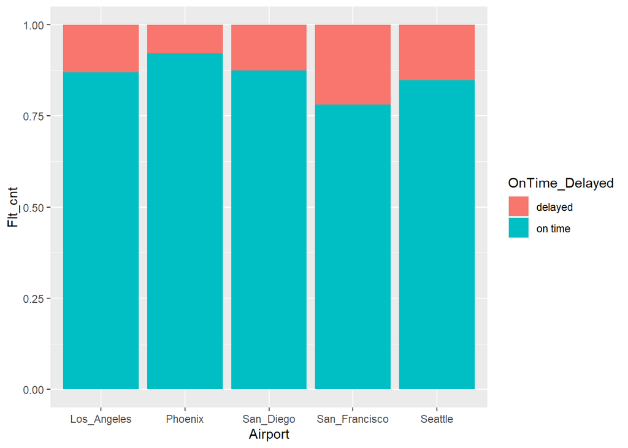

```r
ggplot(perc, aes(fill=OnTime_Delayed, y=Flt_cnt, x=Airport)) +
  geom_bar(position="fill", stat="identity")
```

# Conclusion

After our brief analysis it was found that both airlines have similar delay rates. Initially, by only looking at counts it seemed as if AM WEST airline provides lower quality service than ALAKSKA airline. However, our visuals found that the strongest delay correlation is found by comparing airports.